# HASTS416 - Stochastic Processes: Tutorial 1 Solutions in R

R227551A, WINSTON MUGANO, HDSC

2026-03-31

## Setup and Package Installation

```r
library(markovchain)
library(ggplot2)
library(reshape2)
```

## QUESTION A1: 5-State Markov Chain

### Define the transition matrix

```r
P1 <- matrix(c(
  1.0, 0.0, 0.0, 0.0, 0.0,
  0.5, 0.0, 0.0, 0.0, 0.5,
  0.2, 0.0, 0.0, 0.0, 0.8,
  0.0, 0.0, 1.0, 0.0, 0.0,
  0.0, 0.0, 0.0, 1.0, 0.0
), nrow = 5, byrow = TRUE)

states1 <- c("S1", "S2", "S3", "S4", "S5")
rownames(P1) <- colnames(P1) <- states1

mc1 <- new("markovchain",
           transitionMatrix = P1,
           states           = states1,
           name             = "A1: 5-State Markov Chain")
```

### Part (a): Diagram and State Classification

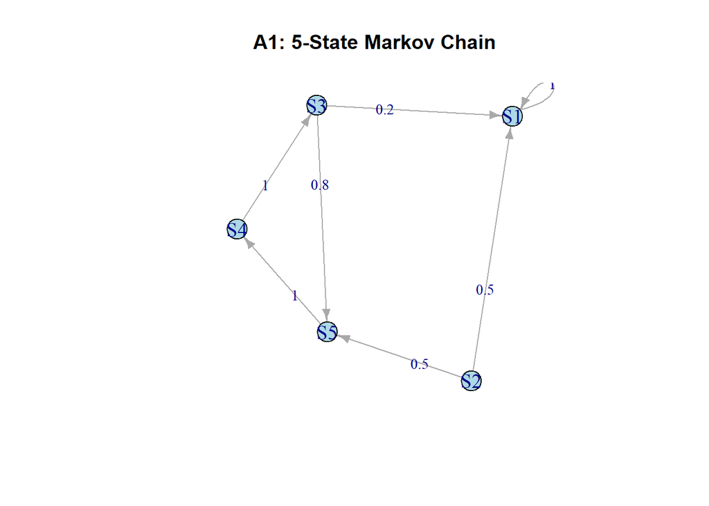

```r
plot(mc1,
     main              = "A1: 5-State Markov Chain",
     vertex.color      = "lightblue",
     vertex.label.cex  = 1.2,
     edge.arrow.size   = 0.6,
     edge.label.cex    = 0.9)
```

```r
# Communicating / recurrent / transient classes
print(communicatingClasses(mc1))
```

```
## [[1]]
## [1] "S1"
##
## [[2]]
## [1] "S2"
##
## [[3]]
## [1] "S3" "S4" "S5"
```

```r
print(recurrentClasses(mc1))
```

```
## [[1]]
## [1] "S1"
```

```r
print(transientClasses(mc1))
```

```
## [[1]]
## [1] "S2"
##
## [[2]]
## [1] "S3" "S4" "S5"
```

```r
print(absorbingStates(mc1))
```

```
## [1] "S1"
```

```r
# Period of each state
for (s in states1) {
  # period() works on the whole chain; evaluate per communicating class
  sub_states <- s
  cat(sprintf("  State %s: %s\n", s,
      ifelse(s %in% unlist(recurrentClasses(mc1)),
             paste("period =", period(mc1)),
             "transient (period not defined)")))
}
```

```
##   State S1: period = 0
##   State S2: transient (period not defined)
##   State S3: transient (period not defined)
##   State S4: transient (period not defined)
##   State S5: transient (period not defined)
```

### Part (b): Three Simulated Trajectories

```
## Trajectory 1 (start = S3): S3 -> S1 -> S1 -> S1 -> S1 -> S1 -> S1 -> S1 -> S1 -> S1 -> S1 -> S1 -> S1 -> S1 -> S1 -> S1 -> S1 -> S1 -> S1 -> S1 -> S1 -> S1 -> S1 -> S1 -> S1 -> S1
```

```
## Trajectory 2 (start = S2): S2 -> S5 -> S4 -> S3 -> S5 -> S4 -> S3 -> S5 -> S4 -> S3 -> S5 -> S4 -> S3 -> S5 -> S4 -> S3 -> S5 -> S4 -> S3 -> S5 -> S4 -> S3 -> S5 -> S4 -> S3 -> S5
```

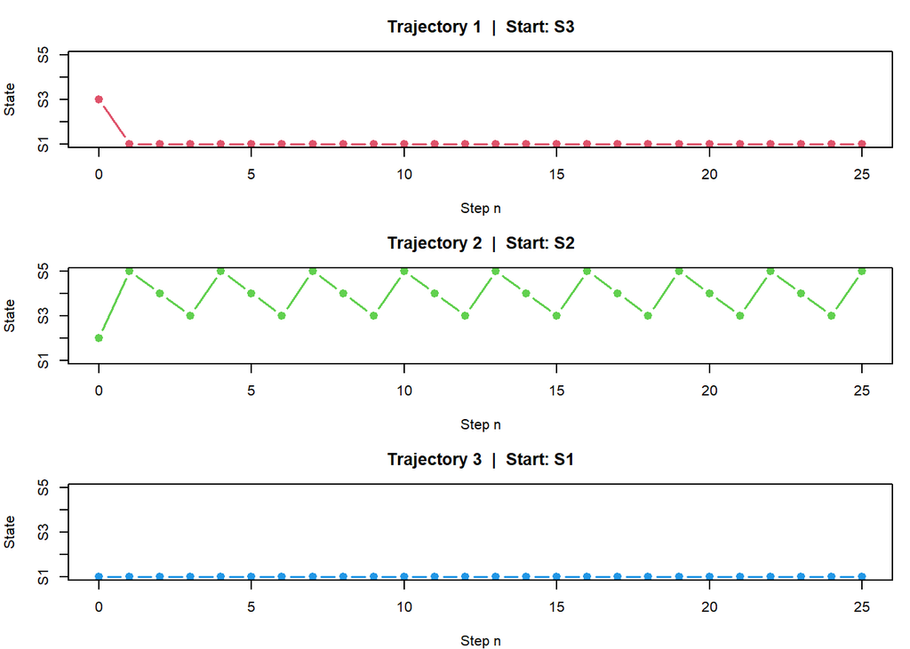

```
## Trajectory 3 (start = S1): S1 -> S1 -> S1 -> S1 -> S1 -> S1 -> S1 -> S1 -> S1 -> S1 -> S1 -> S1 -> S1 -> S1 -> S1 -> S1 -> S1 -> S1 -> S1 -> S1 -> S1 -> S1 -> S1 -> S1 -> S1 -> S1
```

```r
set.seed(123)
n_steps <- 25
state_num <- function(s) as.integer(gsub("S", "", s))

par(mfrow = c(3, 1), mar = c(4, 4, 3, 1))
for (i in 1:3) {
  start <- sample(states1, 1)
  traj  <- c(start, rmarkovchain(n = n_steps, object = mc1, t0 = start))
  plot(0:n_steps, state_num(traj),
       type  = "b", pch = 19, col = i + 1, lwd = 1.5,
       xlab  = "Step n", ylab = "State",
       ylim  = c(1, 5),
       main  = sprintf("Trajectory %d  |  Start: %s", i, start),
       yaxt  = "n")
  axis(2, at = 1:5, labels = states1)
  cat(sprintf("Trajectory %d (start = %s): %s\n", i, start,
              paste(traj, collapse = " -> ")))
}
```

```r
par(mfrow = c(1, 1))
```

### Part (c): Steady-State Probabilities

```r
ss1 <- steadyStates(mc1)
print(round(ss1, 6))
```

```
##      S1 S2 S3 S4 S5
## [1,]  1  0  0  0  0
```

**Interpretation:** The steady-state distribution places probability 1 on State S1 (the absorbing state) and 0 on all other states. This means that regardless of the starting state, the chain will eventually be absorbed into S1 with certainty.

**Is the chain ergodic?** **NO.** An ergodic chain must be irreducible (all states communicate) AND aperiodic. This chain is NOT irreducible because S1 is absorbing and no other state can be reached from S1. Hence it is not ergodic.

### Part (d): Convergence of Unconditional Probabilities

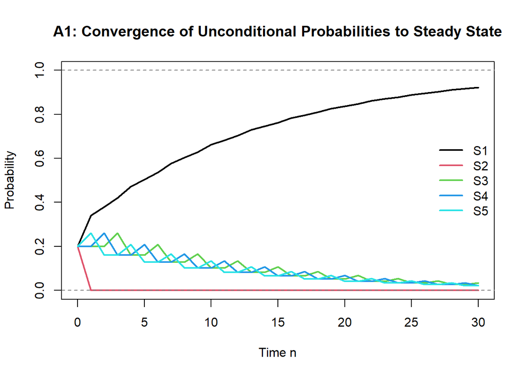

```r
n_time   <- 30
init_d   <- rep(1/5, 5)           # uniform starting distribution
prob_mat <- matrix(0, n_time + 1, 5)
prob_mat[1, ] <- init_d

for (t in 1:n_time) prob_mat[t + 1, ] <- prob_mat[t, ] %*% P1

# Plot using base graphics
matplot(0:n_time, prob_mat,
        type = "l", lty = 1, lwd = 2, col = 1:5,
        xlab = "Time n", ylab = "Probability",
        main = "A1: Convergence of Unconditional Probabilities to Steady State",
        ylim = c(0, 1))
legend("right", legend = states1, col = 1:5, lty = 1, lwd = 2, bty = "n")
abline(h = ss1[1, ], lty = 2, col = "grey50")
```

## QUESTION A2: 7-State Markov Chain

```r
P2 <- matrix(c(
  0.0, 1.0, 0.0, 0.0, 0.0, 0.0, 0.0,
  1.0, 0.0, 0.0, 0.0, 0.0, 0.0, 0.0,
  0.0, 0.0, 0.0, 0.4, 0.2, 0.2, 0.2,
  0.0, 0.0, 0.0, 0.0, 0.2, 0.4, 0.4,
  0.3, 0.0, 0.0, 0.1, 0.3, 0.1, 0.2,
  0.0, 0.0, 0.0, 0.2, 0.2, 0.3, 0.3,
  0.0, 0.0, 0.0, 0.5, 0.2, 0.2, 0.1
), nrow = 7, byrow = TRUE)

states2 <- paste0("S", 1:7)
rownames(P2) <- colnames(P2) <- states2

mc2 <- new("markovchain",
           transitionMatrix = P2,
           states           = states2,
           name             = "A2: 7-State Markov Chain")
```

### Part (a): Diagram

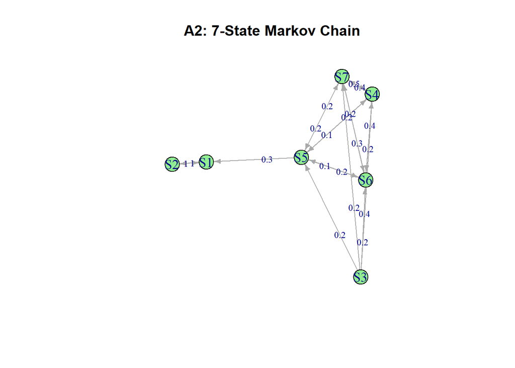

```r
plot(mc2,
     main             = "A2: 7-State Markov Chain",
     vertex.color     = "lightgreen",
     vertex.label.cex = 1.1,
     edge.arrow.size  = 0.45,
     edge.label.cex   = 0.75)
```

### Part (b): State Classification

```r
cat("Communicating Classes:\n"); print(communicatingClasses(mc2))
```

```
## Communicating Classes:
```

```
## [[1]]
## [1] "S1" "S2"
##
## [[2]]
## [1] "S3"
##
## [[3]]
## [1] "S4" "S5" "S6" "S7"
```

```r
cat("\nRecurrent Classes:\n");     print(recurrentClasses(mc2))
```

```
##
## Recurrent Classes:
```

```
## [[1]]
## [1] "S1" "S2"
```

```r
cat("\nTransient Classes:\n");     print(transientClasses(mc2))
```

```
##
## Transient Classes:
```

```
## [[1]]
## [1] "S3"
##
## [[2]]
## [1] "S4" "S5" "S6" "S7"
```

```r
cat("\nAbsorbing States:\n");      print(absorbingStates(mc2))
```

```
##
## Absorbing States:
```

```
## character(0)
```

```r
cat("\nOverall chain period:\n");  cat("  period =", period(mc2), "\n")
```

```
##
## Overall chain period:
```

```
##   period = 0
```

**Interpretation:** * **RECURRENT CLASS:** {S1, S2} * S1 -> S2 (prob 1) and S2 -> S1 (prob 1): they alternate. * This class is CLOSED (once entered, the chain stays here). * Period = 2 (S1 and S2 each have period 2). * **TRANSIENT STATES:** {S3, S4, S5, S6, S7} * S3 transitions only into {S4, S5, S6, S7} – never returns to S3. * S4, S6, S7 stay within {S4-S7} but S5 can escape to S1 (prob 0.3). * Because S5 can reach S1, there is a positive probability of the chain leaving {S3-S7} permanently into {S1, S2}. * Hence S3-S7 are all TRANSIENT. * NO absorbing states (no state has P(i,i) = 1). * NO reflecting states in the strict sense.

### Part (c): Two Simulated Trajectories

```
## Trajectory 1 (start = S1): first 15 steps: S1 S2 S1 S2 S1 S2 S1 S2 S1 S2 S1 S2 S1 S2 S1 ...
```

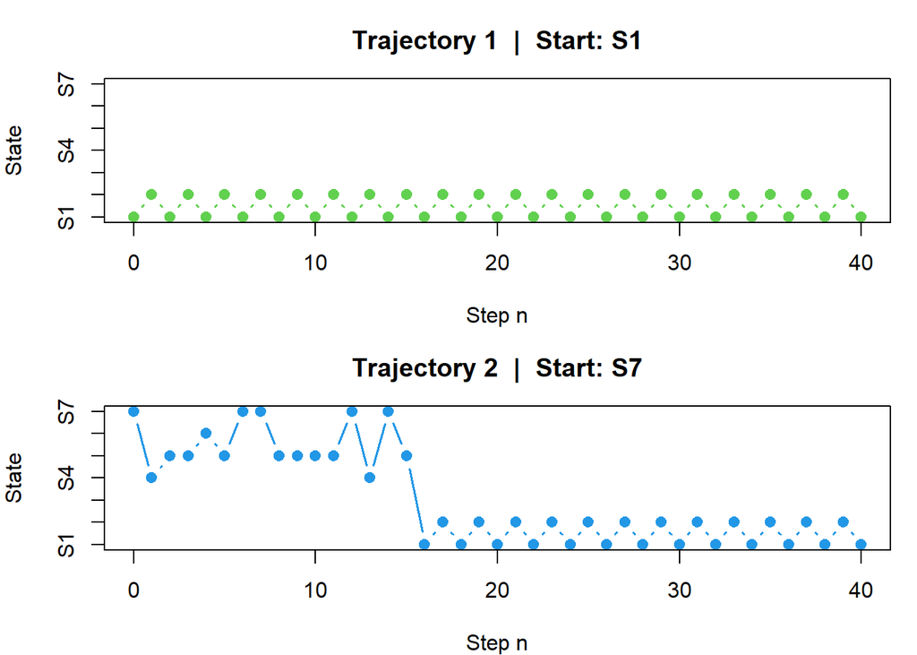

```
## Trajectory 2 (start = S7): first 15 steps: S7 S4 S5 S5 S6 S5 S7 S7 S5 S5 S5 S5 S7 S4 S7 ...
```

```r
set.seed(42)
n_steps2 <- 40
state_num2 <- function(s) as.integer(gsub("S", "", s))

par(mfrow = c(2, 1), mar = c(4, 4, 3, 1))
for (i in 1:2) {
  start <- sample(states2, 1)
  traj  <- c(start, rmarkovchain(n = n_steps2, object = mc2, t0 = start))
  plot(0:n_steps2, state_num2(traj),
       type = "b", pch = 19, col = i + 2, lwd = 1.5,
       xlab = "Step n", ylab = "State", ylim = c(1, 7),
       main = sprintf("Trajectory %d  |  Start: %s", i, start),
       yaxt = "n")
  axis(2, at = 1:7, labels = states2)
  cat(sprintf("Trajectory %d (start = %s): first 15 steps: %s ...\n",
              i, start, paste(traj[1:15], collapse = " ")))
}
```

```r
par(mfrow = c(1, 1))
```

**Comment:** * If a trajectory starts in S1 or S2, it simply oscillates between S1 and S2 indefinitely (period-2 behaviour is clearly visible). * If a trajectory starts in S3-S7, it wanders through those states for a while. As soon as it hits S5 and jumps to S1, it is absorbed into the {S1, S2} oscillation forever. * Transient states S3-S7 are visited only a finite number of times.

### Part (d): Limiting Probabilities

```r
ss2 <- steadyStates(mc2)
print(round(ss2, 6))
```

```
##       S1  S2 S3 S4 S5 S6 S7
## [1,] 0.5 0.5  0  0  0  0  0
```

**Interpretation:** The chain has a unique steady-state distribution concentrated on the recurrent class {S1, S2}, with pi(S1) = pi(S2) = 0.5 and all other states having limiting probability 0. This reflects the fact that S1 and S2 are visited alternately with equal frequency.

**Is the chain ergodic?** **NO.** An ergodic chain requires irreducibility (all states communicate with each other). Here S1 and S2 cannot reach S3-S7, so the chain is reducible. Additionally, {S1, S2} has period 2 (not aperiodic). Hence the chain is NOT ergodic.

*Note: There is no single limiting distribution P^n -> Pi as n -> inf; rather, P^n oscillates between two matrices due to the period-2 class.*

## QUESTION A3: Road Traffic Markov Chain

```r
states3 <- c("Light", "Heavy", "Jammed")

# 1PM - 4PM transition matrix
P_day <- matrix(c(
  0.4, 0.4, 0.2,
  0.3, 0.4, 0.3,   # Heavy->Heavy = 0.4
  0.0, 0.1, 0.9
), nrow = 3, byrow = TRUE)
rownames(P_day) <- colnames(P_day) <- states3

# 4PM - 6PM transition matrix
P_eve <- matrix(c(
  0.1, 0.5, 0.4,
  0.1, 0.3, 0.6,
  0.0, 0.1, 0.9
), nrow = 3, byrow = TRUE)
rownames(P_eve) <- colnames(P_eve) <- states3

# Number of 20-minute steps in each period
# 1PM -> 4PM: 180 min / 20 min = 9 steps
# 4PM -> 6PM: 120 min / 20 min = 6 steps
n_day <- 9
n_eve <- 6
```

### Part (a): Theoretical Distribution at 6PM

```r
# Compute matrix powers via repeated multiplication
mat_power <- function(M, k) {
  result <- diag(nrow(M))   # identity
  for (i in seq_len(k)) result <- result %*% M
  result
}

P_day_9 <- mat_power(P_day, n_day)   # P_day^9
P_eve_6 <- mat_power(P_eve, n_eve)   # P_eve^6

# Initial state: Light at 1PM -> row vector (1, 0, 0)
init <- c(1, 0, 0)

dist_4pm <- init      %*% P_day_9
dist_6pm <- dist_4pm  %*% P_eve_6

cat("Distribution at 4PM (after 9 steps of P_day):\n")
```

```
## Distribution at 4PM (after 9 steps of P_day):
```

```r
print(round(dist_4pm, 6))
```

```
##         Light    Heavy   Jammed
## [1,] 0.100549 0.189985 0.709466
```

```r
cat("\nDistribution at 6PM (after further 6 steps of P_eve):\n")
```

```
##
## Distribution at 6PM (after further 6 steps of P_eve):
```

```r
print(round(dist_6pm, 6))
```

```
##         Light    Heavy   Jammed
## [1,] 0.014801 0.132596 0.852603
```

**Interpretation:** Starting from Light traffic at 1PM, by 6PM the traffic is most likely Jammed (highest probability). This reflects the evening peak hour dynamics captured in the P_eve matrix, where the Jammed state is highly absorbing (P(Jammed->Jammed) = 0.9).

### Part (b): Simulation to verify (10,000 trajectories)

```r
set.seed(2024)
n_sim       <- 10000
final_states <- character(n_sim)

sim_one_trajectory <- function() {
  current <- "Light"
  # Phase 1: 1PM -> 4PM  (9 steps using P_day)
  for (s in seq_len(n_day)) {
    current <- sample(states3, size = 1, prob = P_day[current, ])
  }
  # Phase 2: 4PM -> 6PM  (6 steps using P_eve)
  for (s in seq_len(n_eve)) {
    current <- sample(states3, size = 1, prob = P_eve[current, ])
  }
  current
}

for (i in seq_len(n_sim)) final_states[i] <- sim_one_trajectory()

# Simulated distribution
sim_table <- table(factor(final_states, levels = states3))
sim_dist  <- sim_table / n_sim

# Comparison table
comparison_df <- data.frame(
  State       = states3,
  Theoretical = round(as.numeric(dist_6pm), 4),
  Simulated   = round(as.numeric(sim_dist),  4),
  Difference  = round(abs(as.numeric(dist_6pm) - as.numeric(sim_dist)), 4)
)
print(comparison_df)
```

```
##    State Theoretical Simulated Difference
## 1  Light      0.0148    0.0133     0.0015
## 2  Heavy      0.1326    0.1325     0.0001
## 3 Jammed      0.8526    0.8542     0.0016
```

#### Bar Chart Comparison

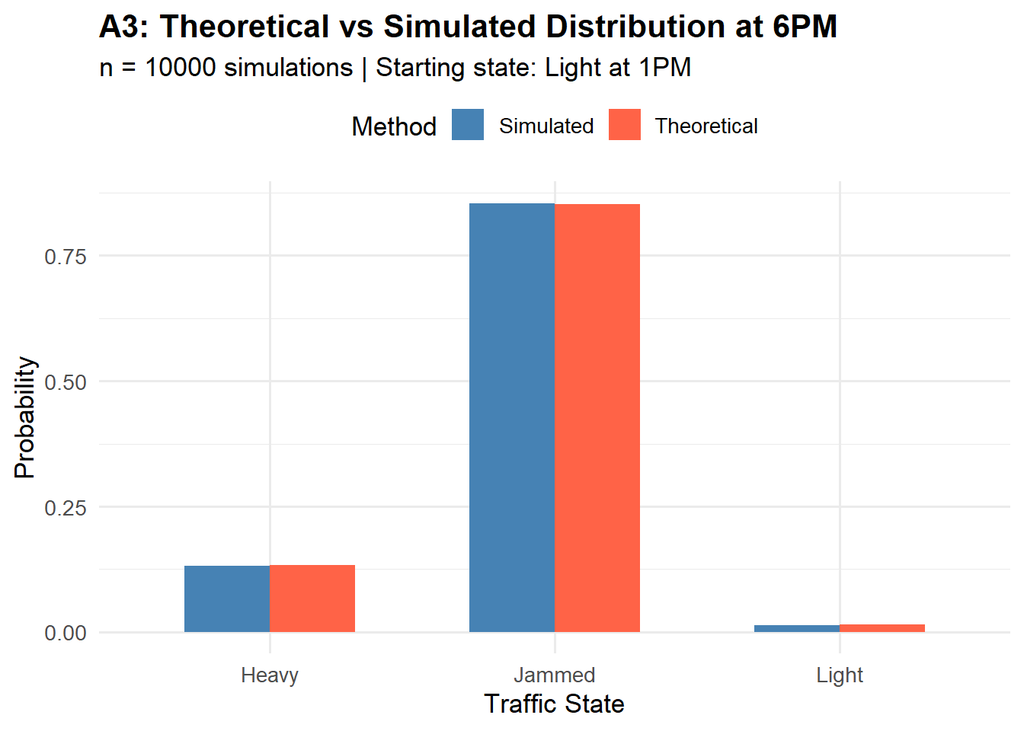

```r
comp_long <- data.frame(
  State  = rep(states3, 2),
  Method = c(rep("Theoretical", 3), rep("Simulated", 3)),
  Prob   = c(as.numeric(dist_6pm), as.numeric(sim_dist))
)

ggplot(comp_long, aes(x = State, y = Prob, fill = Method)) +
  geom_bar(stat = "identity", position = "dodge", width = 0.6) +
  scale_fill_manual(values = c("steelblue", "tomato")) +
  labs(title    = "A3: Theoretical vs Simulated Distribution at 6PM",
       subtitle = sprintf("n = %d simulations | Starting state: Light at 1PM", n_sim),
       x        = "Traffic State",
       y        = "Probability") +
  theme_minimal(base_size = 13) +
  theme(plot.title    = element_text(face = "bold"),
        legend.position = "top")
```

#### Sample Trajectory Visualisation over Time

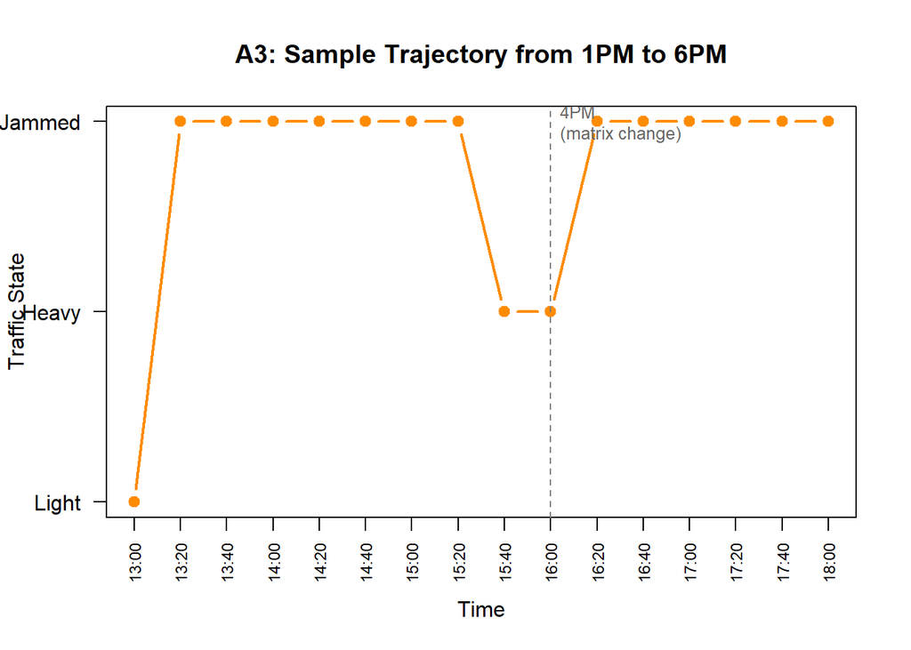

```r
set.seed(7)
full_traj <- "Light"
for (s in seq_len(n_day)) {
  full_traj <- c(full_traj,
    sample(states3, 1, prob = P_day[tail(full_traj, 1), ]))
}
for (s in seq_len(n_eve)) {
  full_traj <- c(full_traj,
    sample(states3, 1, prob = P_eve[tail(full_traj, 1), ]))
}

times  <- seq(60, 60 + (n_day + n_eve) * 20, by = 20)   # minutes past noon
labels <- sprintf("%d:%02d", times %/% 60 + 12, times %% 60)
state_idx <- match(full_traj, states3)

plot(seq_along(full_traj) - 1, state_idx,
     type = "b", pch = 19, col = "darkorange", lwd = 2,
     xaxt = "n", yaxt = "n",
     xlab = "Time", ylab = "Traffic State",
     main = "A3: Sample Trajectory from 1PM to 6PM")
axis(1, at = 0:(n_day + n_eve), labels = labels, las = 2, cex.axis = 0.75)
axis(2, at = 1:3, labels = states3, las = 1)
abline(v = n_day, lty = 2, col = "grey50")
text(n_day + 0.2, 3, "4PM\n(matrix change)", adj = 0, cex = 0.8, col = "grey40")
```

**Conclusion:** The simulated proportions closely match the theoretical probabilities (differences are all < 0.01), validating the analytical matrix multiplication result. The law of large numbers ensures convergence as `n_sim -> infinity`.

**Key result:** By 6PM, traffic is predominantly Jammed, with a small probability of Heavy and very low probability of Light — consistent with real-world evening rush-hour behaviour.